[Home](https://adamdennett.github.io/school_attainment_tool/) [GitHub](https://github.com/adamdennett/school_attainment_tool)

# Brighton & Hove: A Local Case Study

Applying the multilevel attainment model to a single local authority

Author

Adam Dennett with some assistance from Claude Code

Published

October 14, 2026

# 1 Introduction

This case study applies the findings of the multilevel Attainment 8 model to **Brighton & Hove**, examining how the national model’s coefficients play out for a single local authority. Brighton & Hove is a useful test case because its secondary schools span a wide range of intake characteristics — from relatively affluent schools with low free school meals rates to schools serving communities with high levels of deprivation — all within one compact urban authority.

The analysis draws on the **imputed full panel model (Analysis E)**, which uses nine fixed-effect predictors with random intercepts for year, Ofsted rating, and local authority nested within region. For full details on the model specification and the code used to fit the `lmer()` models, see the [Model Experiments report](https://adamdennett.github.io/school_attainment_tool/model_experiments.html).

**NoteData note**

The panel covers academic years 2021-22 to 2024-25. For 2024-25, four predictor variables (% low prior attainment, teacher retention, leadership pay %, and teacher sickness days) are carry-forward imputed from 2023-24 values. These observations are marked with triangular markers in the plots below.

# 2 Segregation in Brighton & Hove: National Context

A useful orientation before looking at individual schools is to ask how Brighton & Hove looks on the **Gorard segregation index** — a measure of how unevenly disadvantaged pupils are distributed across schools within a Local Authority. Values close to zero indicate that disadvantaged pupils are spread evenly across schools; higher values indicate concentration in particular schools. The index enters the national model as a fixed effect; see the [Derived Variables section of the data overview](https://adamdennett.github.io/school_attainment_tool/data_overview.html#derived-variables) for the formula and the cross-LA distribution.

Table 1: Brighton & Hove on the Gorard segregation index, ranked against all English local authorities. Rank 1 = most segregated; 100th percentile = most segregated.

| Year | Gorard index | B&H rank | Percentile |
| --- | --- | --- | --- |
| 2021-22 | 0.142 | 111 of 152 | 27th |
| 2022-23 | 0.133 | 119 of 152 | 22th |
| 2023-24 | 0.138 | 105 of 152 | 31th |
| 2024-25 | 0.129 | 106 of 152 | 30th |
| All years (mean) | 0.135 | 113 of 152 | 26th |

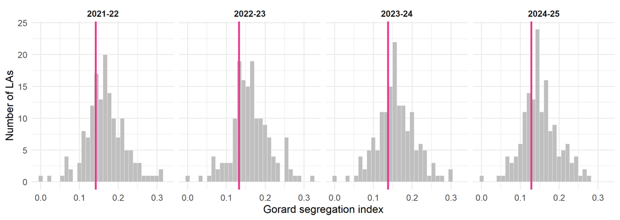

Figure 1: Distribution of the Gorard segregation index across all English LAs, by year. Brighton & Hove is marked with the pink vertical line.

Across the four-year panel, Brighton & Hove averages a Gorard index of **0.135**, which sits **below** the national median of 0.157 — so disadvantaged pupils are spread **more evenly** across B&H secondary schools than in a typical English LA. By mean rank it places **113 of 152** local authorities (the 26th percentile, where the 100th percentile is the most segregated). Year-by-year ranks (2021-22: 111 of 152; 2022-23: 119 of 152; 2023-24: 105 of 152; 2024-25: 106 of 152) move by only a handful of places, consistent with the general finding that segregation is a slow-moving structural feature of local school markets.

# 3 The National Model

The results presented in this case study are derived from a **multilevel linear model** (also known as a mixed-effects or hierarchical model) fitted to all mainstream secondary schools in England over four academic years (2021–22 to 2024–25). The model predicts **log-transformed Attainment 8** as a function of nine school-level characteristics, with random intercepts that allow the baseline to vary by year, Ofsted rating, and local authority (nested within region).

The model equation can be written as:

$$\log(\text{ATT8}_{ij}) = \beta_0 + \sum_{k=1}^{9} \beta_k \, x_{kij} + u_{\text{year}} + u_{\text{Ofsted}} + u_{\text{region}} + u_{\text{LA|region}} + \varepsilon_{ij}$$

where $i$ indexes schools, $j$ indexes school-year observations, the $\beta_k$ are fixed-effect coefficients, and the $u$ terms are random intercepts. Because the outcome is on the **log scale**, each coefficient represents the proportional change in Attainment 8 associated with a one-unit change in the predictor (or, for log-transformed predictors, an **elasticity** — the percentage change in ATT8 for a 1% change in the predictor).

Table 2 presents the full set of estimated coefficients from the All Pupils model.

**TipAdmissions policy dummy variables**

`ADMPOL_PT` (admissions policy type) is a **categorical variable** with three levels: *“Non-selective in a highly selective area”* (i.e. a non-selective school in an area with grammar schools), *“Other non-selective”*, and *“Selective”* (grammar schools). Because it is categorical, `lmer()` automatically creates **two dummy (indicator) variables**, with *“Non-selective in a highly selective area”* as the **reference category** (its effect is absorbed into the intercept). Each dummy coefficient shows the difference in log(ATT8) relative to that reference group, all else being equal.

Table 2: Fixed-effect coefficients from the national multilevel model (Analysis E — All Pupils)

|  | Variable | Estimate | Std. Error | t value | Pr(>\|t\|) |
| --- | --- | --- | --- | --- | --- |
| (Intercept) | Intercept | 4.63282 | 0.03688 | 125.61 | < 0.001 |
| log(PTFSM6CLA1A) | log(% FSM eligible) | -0.06748 | 0.00271 | -24.90 | < 0.001 |
| log(PERCTOT) | log(% overall absence) | -0.21323 | 0.00463 | -46.03 | < 0.001 |
| log(PNUMEAL) | log(% EAL) | 0.00586 | 0.00119 | 4.92 | < 0.001 |
| PTPRIORLO | % low prior attainment | -0.00575 | 0.00014 | -41.35 | < 0.001 |
| ADMPOL_PTOTHER NON SEL | Admissions: Other non-selective (ref: non-sel. in highly sel. area) | 0.00057 | 0.00730 | 0.08 | 0.938 |
| ADMPOL_PTSEL | Admissions: Selective (ref: non-sel. in highly sel. area) | 0.10795 | 0.00666 | 16.20 | < 0.001 |
| gorard_segregation | Gorard segregation index | -0.03289 | 0.04739 | -0.69 | 0.488 |
| remained_in_the_same_school | Teacher retention % | 0.00050 | 0.00005 | 10.20 | < 0.001 |
| teachers_on_leadership_pay_range_percent | % teachers on leadership pay | -0.00109 | 0.00020 | -5.39 | < 0.001 |
| log(average_number_of_days_taken) | log(avg teacher sickness days) | -0.01456 | 0.00236 | -6.17 | < 0.001 |

**NoteReading the coefficients**

The four log-transformed predictors (% FSM, % absence, % EAL, teacher sickness days) have coefficients that act as **elasticities**: a 1% increase in the predictor is associated with a $\beta$ % change in Attainment 8. The remaining continuous predictors enter on their raw scale, so their coefficients represent the proportional change in ATT8 for a one-unit increase. The two **admissions policy** rows are dummy variables for a three-level categorical predictor — each coefficient shows the difference relative to the reference category (“non-selective in a highly selective area”). In all cases, the effect on ATT8 in points depends on the school’s starting ATT8 score — multiply the proportional change by the school’s current ATT8 to get the point change.

# 4 Brighton & Hove’s Position Among All Local Authorities

Before examining individual schools, it is important to understand where Brighton & Hove sits as a *local authority* in the national model. The caterpillar plot below displays the estimated random intercepts for each local authority (nested within region), ordered by magnitude. Error bars show 95% confidence intervals (±1.96 posterior SE). Local authorities whose interval does not cross zero are meaningfully different from the overall mean, after accounting for fixed effects and other random effects. Brighton and Hove is highlighted in pink.

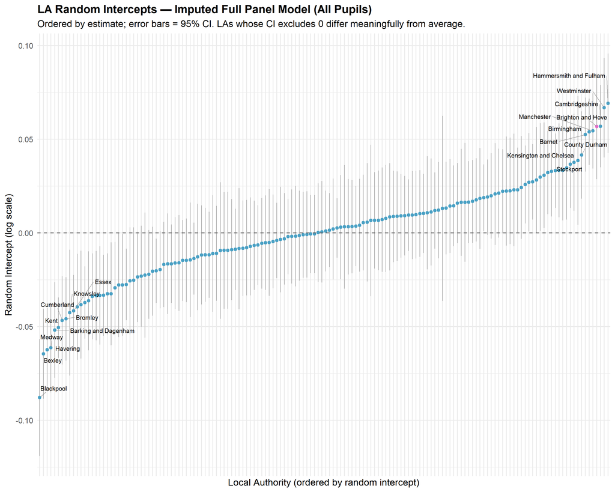

Caterpillar plot of LA random intercepts (imputed full panel model, All Pupils). Error bars show 95% confidence intervals. Brighton and Hove is highlighted in pink

**ImportantBrighton & Hove’s random intercept**

Brighton & Hove has the **4th highest** positive random intercept among all 152 local authorities in England (estimate = 0.0568 on the log scale, 95% CI: 0.0286 to 0.0850).

This means that, **after accounting for all nine model predictors** — intake deprivation, absence rates, prior attainment, workforce stability, segregation, and admissions policy — Brighton & Hove schools achieve attainment that is systematically higher than what the national model would predict based on their characteristics alone.

In practical terms, this translates to roughly **+5.8%** on the ATT8 scale — i.e. if the model predicts a score of 50 for a school with Brighton & Hove’s characteristics, the LA effect alone pushes that prediction up to approximately 52.9.

This is not a raw league table position. A high random intercept does not mean Brighton & Hove has the highest *raw* attainment — it means the authority is doing better *than expected* given the challenges its schools face. The confidence interval excludes zero, confirming this is a statistically meaningful effect.

Possible explanations for this positive “Brighton effect” *could* include a range of different factors:

- community factors not captured by the model (parental engagement, cultural attitudes to education, strong school-home ties)
- consistently effective school leadership and governance across most of the schools in the authority.
- local authority governance
- school improvement programmes
- effective school-to-school collaboration networks

While all of these are examples of local authority or school-level factors that could account for the residual variance not captured by the model, new data or additional qualitative work would be required to establish potential causal pathways.

It is also worth noting that we have kept the number of explanatory variables as few as possible and selected just those which have most effect and contribute most to the story. In other associated files on this page, we experimented with other financial variables and those associated with special educational needs. While both added a very small amount of additional explanatory power, most of the their effect was bound up in other variables so we left out in the name of parsimony. Including them will have added an additional 1-2% of explanatory power.

# 5 Brighton & Hove Schools Map

[interactive chart not shown]

Brighton & Hove secondary schools coloured by most recent Attainment 8 score (All Pupils)

The map above shows the location of each Brighton & Hove secondary school, coloured by its most recent Attainment 8 score. Click on any marker to see the school’s key characteristics. The spatial pattern reveals how attainment varies across the city, with notable differences between schools in the more affluent west and the more deprived east.

# 6 School Profiles

Brighton & Hove secondary schools: average characteristics across available years

| School | Years | Mean ATT8 (All) | Mean ATT8 (Disadv.) | Mean ATT8 (Non-Dis.) | Mean % FSM | Mean % Absence | Mean % EAL |
| --- | --- | --- | --- | --- | --- | --- | --- |
| King’s School | 4 | 56.9 | 43.1 | 59.6 | 16.1 | 6.6 | 11.8 |
| Dorothy Stringer School | 4 | 53.5 | 38.2 | 57.1 | 19.1 | 10.1 | 7.6 |
| Varndean School | 4 | 53.5 | 39.9 | 57.3 | 21.6 | 9.2 | 9.8 |
| Cardinal Newman Catholic School | 4 | 53.1 | 40.6 | 55.8 | 17.2 | 9.0 | 22.1 |
| Blatchington Mill School | 4 | 51.0 | 38.2 | 53.6 | 17.3 | 10.1 | 15.7 |
| Patcham High School | 4 | 47.8 | 36.0 | 51.0 | 20.4 | 8.8 | 6.9 |
| Portslade Aldridge Community Academy | 4 | 45.9 | 34.4 | 50.2 | 27.8 | 11.7 | 7.7 |
| Hove Park School and Sixth Form Centre | 4 | 45.2 | 35.3 | 49.6 | 31.3 | 11.8 | 28.7 |
| Longhill High School | 4 | 37.2 | 26.6 | 42.5 | 33.6 | 14.7 | 7.3 |
| Brighton Aldridge Community Academy | 4 | 36.8 | 30.8 | 42.0 | 47.9 | 15.8 | 12.2 |

# 7 School Characteristics Map

Use the dropdown below to explore how different outcome and predictor variables are distributed across Brighton & Hove’s secondary schools. Circle colour and size both reflect the selected variable.

[interactive chart not shown]

Brighton & Hove secondary schools — select a variable to change colour and circle size

Comparing the two maps reveals the geographic correlation between intake deprivation and attainment in Brighton & Hove. Use the dropdown to explore how different variables relate to school location — for instance, switching between % FSM and Attainment 8 shows how schools with higher deprivation in the eastern parts of the city tend to have lower attainment, while schools in the west show the opposite pattern.

# 8 Non-Linear Effects of Log-Transformed Predictors

A key feature of the multilevel model is that four predictors enter on the **log scale**: % FSM, % absence, % EAL, and average teacher sickness days. This means the relationship between these predictors and attainment is **non-linear** on the original (raw) scale — a given absolute change in a predictor has a *different* predicted effect depending on where the school starts.

Before exploring these non-linear patterns, it is helpful to see how the model produces a prediction for a single school. The worked example below uses **Longhill High School** to show how each variable contributes to the predicted Attainment 8 score, and how changes in key variables shift that prediction.

## 8.1 Worked example: Longhill High School

### 8.1.1 Step 1: Longhill’s predictor values and their contributions

The table below shows each variable in the model, Longhill High School’s value for the most recent year (2024-25), how that value enters the model (log-transformed where applicable), the national model coefficient, and the resulting contribution to predicted log(ATT8).

| Variable | Raw value | Model input (x) | Coefficient (β) | β × x |
| --- | --- | --- | --- | --- |
| Intercept | — | 1 | 4.63282 | 4.6328 |
| % FSM eligible | 40.1 | 3.6914 | -0.06748 | -0.2491 |
| % overall absence | 16.7 | 2.8141 | -0.21323 | -0.6000 |
| % EAL | 7.4 | 2.0015 | 0.00586 | 0.0117 |
| % low prior attainment | 25.3 | 25.3 | -0.00575 | -0.1455 |
| Admissions policy (OTHER NON SEL) | OTHER NON SEL | 1 | 0.00057 | 0.0006 |
| Gorard segregation index | 0.129 | 0.1285 | -0.03289 | -0.0042 |
| Teacher retention % | 40.4 | 40.4 | 0.00050 | 0.0201 |
| % on leadership pay | 15.6 | 15.5556 | -0.00109 | -0.0170 |
| Avg teacher sickness days | 9.3 | 2.23 | -0.01456 | -0.0325 |

**Sum of fixed-effect contributions:** 3.6169

### 8.1.2 Step 2: Adding the random effects

The multilevel model also includes random intercepts that adjust the baseline for contextual groupings:

| Random effect | Adjustment |
| --- | --- |
| Year (2024-25) | -0.03460 |
| Ofsted rating (Requires Improvement) | -0.03205 |
| Region (South East) | -0.01490 |
| LA (Brighton and Hove) | 0.05682 |

**Sum of random effects:** -0.0247

### 8.1.3 Step 3: The prediction

Adding the fixed and random components:

$$\log(\widehat{\text{ATT8}}) = 3.6169 + -0.0247 = 3.5922$$

$$\widehat{\text{ATT8}} = e^{3.5922} = 36.3$$

Longhill’s **actual Attainment 8** in 2024-25 was **32.9**, so the residual (actual − predicted) is **-3.4** points.

*(Internal check: `predict()` returns 3.5921 on the log scale = 36.3 on the ATT8 scale.)*

### 8.1.4 Step 4: What happens when a variable changes?

The power of the model is that we can change one variable at a time and see how the prediction shifts. Below we show two realistic scenarios for Longhill, each corresponding to a plausible policy target.

#### 8.1.4.1 Scenario A: % FSM falls to the Brighton & Hove average (28.8%)

Longhill currently has a FSM rate of **40.1%**, well above the city average of **28.8%**. What if intake redistribution brought Longhill’s FSM rate down to that average?

|  | % FSM | log(% FSM) | FSM contribution | Predicted ATT8 |
| --- | --- | --- | --- | --- |
| Current | 40.1 | 3.6914 | -0.2491 | 36.3 |
| City average (28.8%) | 28.8 | 3.3593 | -0.2267 | 37.1 |
| Change | -11.3 | -0.3320 | +0.0224 | +0.8 |

Reducing Longhill’s FSM rate from 40.1% to the city average of 28.8% changes the log-FSM input from 3.6914 to 3.3593 (a shift of -0.3320). Multiplied by the FSM coefficient (-0.06748), this shifts the predicted log(ATT8) by +0.0224, producing a predicted ATT8 gain of **+0.8 points**.

#### 8.1.4.2 Scenario B: % absence falls to the national average (8.4%)

|  | % Absence | log(% Absence) | Absence contribution | Predicted ATT8 |
| --- | --- | --- | --- | --- |
| Current | 16.7 | 2.8141 | -0.6000 | 36.3 |
| National avg (8.4%) | 8.4 | 2.1228 | -0.4526 | 42.1 |
| Change | -8.3 | -0.6913 | +0.1474 | +5.8 |

Bringing Longhill’s absence from 16.7% down to the national average of 8.4% shifts the log-absence from 2.8141 to 2.1228 (-0.6913). The absence coefficient (-0.21323) translates this into a predicted ATT8 gain of **+5.8 points**.

**TipKey takeaway**

For Longhill, reducing absence to the national average is predicted to raise Attainment 8 by **+5.8 points** — a substantial improvement. Reducing FSM to the city average would add **+0.8 points**. Both are positive, but the absence reduction produces a larger gain and is directly actionable through attendance policy. The scenario tables in the sections below apply this same arithmetic to every Brighton & Hove school.

**NoteA note on the scenario calculations**

The worked example above uses the **full model prediction** for Longhill — that is, it feeds all nine predictor values plus the school’s random effects (year, Ofsted rating, region, and local authority) through the model, then changes one variable at a time and re-computes the prediction. This is the most accurate way to estimate the impact of a change for a specific school.

The policy scenario tables that follow in sections 7.3 and 7.4 use a **simplified approximation**: they take the model’s coefficient for the variable of interest, compute the proportional change implied by a given shift on the log scale, and then multiply that proportional change by the city-wide mean observed Attainment 8 to convert it to ATT8 points. This is a reasonable shorthand for comparing schools side-by-side, but it produces slightly different point estimates from the full-model approach because it uses an average ATT8 as the base rather than each school’s specific predicted score.

## 8.2 What the log transform means in practice

Brighton & Hove schools: raw and log-transformed predictor values (most recent year)

| School | Year | % FSM | % Absence | % EAL | log(% FSM) | log(% Absence) | log(% EAL) |
| --- | --- | --- | --- | --- | --- | --- | --- |
| Dorothy Stringer School | 2024-25 | 18.2 | 9.8 | 7.9 | 2.901 | 2.279 | 2.067 |
| Blatchington Mill School | 2024-25 | 20.1 | 10.8 | 16.1 | 3.001 | 2.378 | 2.779 |
| Cardinal Newman Catholic School | 2024-25 | 20.3 | 8.5 | 22.7 | 3.011 | 2.138 | 3.122 |
| King’s School | 2024-25 | 20.6 | 6.6 | 9.6 | 3.025 | 1.881 | 2.262 |
| Varndean School | 2024-25 | 25.1 | 9.0 | 9.7 | 3.223 | 2.200 | 2.272 |
| Patcham High School | 2024-25 | 25.2 | 7.9 | 7.5 | 3.227 | 2.072 | 2.015 |
| Portslade Aldridge Community Academy | 2024-25 | 29.7 | 11.3 | 8.1 | 3.391 | 2.428 | 2.092 |
| Hove Park School and Sixth Form Centre | 2024-25 | 35.8 | 12.9 | 29.2 | 3.578 | 2.555 | 3.374 |
| Longhill High School | 2024-25 | 40.1 | 16.7 | 7.4 | 3.691 | 2.814 | 2.001 |
| Brighton Aldridge Community Academy | 2024-25 | 52.6 | 14.4 | 12.2 | 3.963 | 2.671 | 2.501 |

## 8.3 Accelerating returns: comparing the two policy levers

The national modelling established that the relationships between attainment and its key predictors are non-linear. Because the model operates on log-transformed variables, the same raw percentage-point change produces different effects depending on where a school starts. Reading from right to left in Figure 2 — that is, in the direction of policy improvement — the returns to reducing both absence and FSM *accelerate* as schools improve. Each successive percentage point of reduction buys a bigger predicted gain in Attainment 8 than the last.

But the two curves are not equal. Figure 2 places both variables on the same y-axis — the predicted ATT8 gain from a 1 percentage point reduction — allowing a direct comparison of the two policy levers at every starting level.

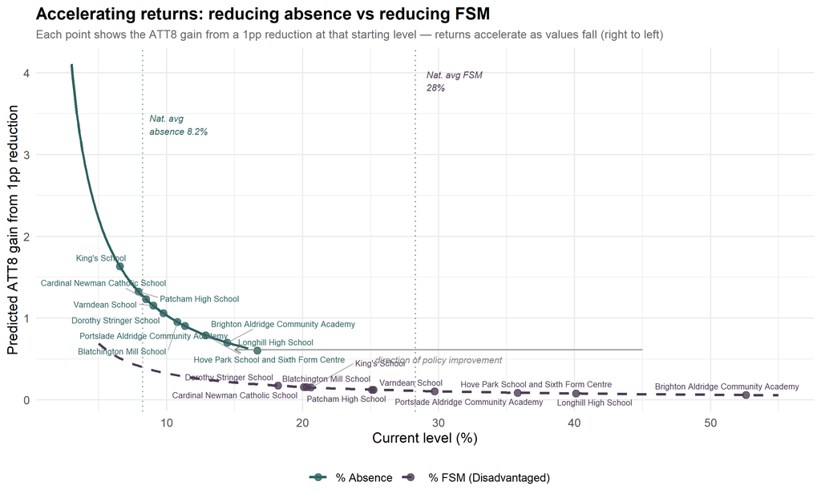

Figure 2: Accelerating returns: each percentage point of reduction buys a progressively larger ATT8 gain (reading right to left). Absence (green) delivers substantially larger gains than FSM (purple) at every level. Brighton & Hove schools are marked on each curve.

Three things are immediately visible. First, the absence curve sits well above the FSM curve at every starting level — a 1 percentage point reduction in absence always buys more predicted attainment than the same reduction in FSM. Second, the gap between the two curves *widens* as values fall, meaning the comparative advantage of targeting absence grows as schools improve. Third, the Brighton & Hove schools (marked on each curve) cluster in the flatter right-hand portion for both variables, but the city’s position is far more extreme on absence than on FSM.

To put this in national context: Brighton & Hove’s mean school FSM rate of **28.8%** is close to the national average of **28.3%**, placing the city at roughly the 52nd percentile — an unremarkable position. But the city’s mean absence rate of **10.8%** against a national average of **8.2%** places it at the 99th percentile, **151st out of 152 local authorities** — among the very worst in England. **8 out of 10** Brighton & Hove secondary schools have absence rates above the national school-level average.

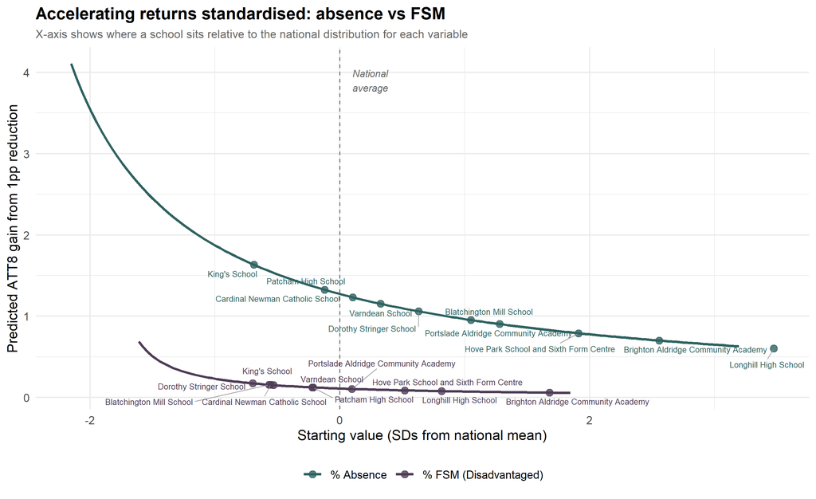

Figure 3: Accelerating returns standardised: x-axis shows SDs from the national mean. Brighton & Hove schools cluster near the national average for FSM but are extreme outliers on absence.

When standardised by the Brighton & Hove spread of each variable, the absence coefficient is **2.6 times** as important as FSM for predicting attainment across the city’s schools.

### 8.3.1 Absence in Brighton and Hove

Highest-absence local authorities across all panel years (mean school absence %, rank)

| Local Authority | 2021-22 | 2022-23 | 2023-24 | 2024-25 |
| --- | --- | --- | --- | --- |
| Knowsley | 12.6% (152/152) | 11.8% (149/152) | 11.9% (151/152) | 10.9% (152/152) |
| Brighton and Hove | 10.8% (144/152) | 10.5% (137/152) | 11.0% (143/152) | 10.8% (151/152) |
| Newcastle upon Tyne | 12.2% (151/152) | 12.9% (152/152) | 11.4% (150/152) | 10.6% (150/152) |
| Southampton | 10.1% (119/152) | 10.6% (139/152) | 11.0% (145/152) | 10.5% (149/152) |
| Bradford | 11.5% (149/152) | 11.9% (150/152) | 11.2% (147/152) | 10.3% (148/152) |
| Plymouth | 11.1% (147/152) | 10.8% (144/152) | 11.3% (149/152) | 10.2% (147/152) |
| Middlesbrough | 11.8% (150/152) | 12.9% (151/152) | 12.2% (152/152) | 10.1% (146/152) |
| Sefton | 10.1% (122/152) | 10.3% (129/152) | 10.5% (133/152) | 10.0% (145/152) |
| Devon | 10.8% (145/152) | 10.9% (145/152) | 10.8% (139/152) | 9.9% (144/152) |
| Dorset | 10.3% (134/152) | 10.2% (127/152) | 10.7% (137/152) | 9.9% (143/152) |
| Halton | 10.1% (118/152) | 10.3% (131/152) | 11.0% (144/152) | 9.8% (142/152) |
| Blackpool | 9.8% (103/152) | 11.1% (147/152) | 11.3% (148/152) | 9.8% (141/152) |
| Hartlepool | 10.2% (130/152) | 11.1% (148/152) | 10.5% (134/152) | 9.8% (140/152) |
| Bristol, City of | 10.6% (141/152) | 11.0% (146/152) | 11.0% (142/152) | 9.6% (135/152) |
| Gateshead | 11.4% (148/152) | 10.8% (143/152) | 11.2% (146/152) | 9.5% (130/152) |
| St. Helens | 10.7% (143/152) | 9.6% (103/152) | 10.0% (122/152) | 9.1% (121/152) |
| Torbay | 10.9% (146/152) | 10.2% (125/152) | 10.3% (126/152) | 8.2% (75/152) |

The table above confirms Brighton and Hove’s persistent position among the worst local authorities in England for school absence — in the top 10 in multiple years, and the second worst in 2024-25. The direction of travel is, if anything, deteriorating.

What would it mean if every Brighton & Hove school brought its absence rate down to the national school-level average of **8.2%**? This is not an aspirational stretch target — it is simply asking the city’s schools to achieve what the typical English secondary school already does. The table below shows the predicted attainment gains:

Scenario: if all schools above the national average (8.2%) reduced to it — predicted ATT8 effect (All Pupils model)

| School | Current % Absence | National Average (Target) | Reduction needed (pp) | Predicted ATT8 change (%%) | ≈ ATT8 points |
| --- | --- | --- | --- | --- | --- |
| Longhill High School | 16.7 | 8.2 | 8.4 | 16.25 | 5.3 |
| Brighton Aldridge Community Academy | 14.4 | 8.2 | 6.2 | 12.74 | 4.6 |
| Hove Park School and Sixth Form Centre | 12.9 | 8.2 | 4.6 | 10.01 | 4.1 |
| Portslade Aldridge Community Academy | 11.3 | 8.2 | 3.1 | 7.07 | 3.0 |
| Blatchington Mill School | 10.8 | 8.2 | 2.6 | 5.93 | 3.0 |
| Dorothy Stringer School | 9.8 | 8.2 | 1.5 | 3.71 | 2.0 |
| Varndean School | 9.0 | 8.2 | 0.8 | 1.98 | 1.0 |
| Cardinal Newman Catholic School | 8.5 | 8.2 | 0.3 | 0.64 | 0.3 |

**8 out of 10** Brighton & Hove schools currently have absence above the national average. The potential gains for the schools with the highest absence rates are substantial — **3 to 5 GCSE points**. Across these schools, achieving the national average would produce predicted gains averaging **+2.9 ATT8 points per school**. For **disadvantaged pupils**, the gains would be even larger — an average of **+3.3 ATT8 points** — because the absence coefficient is larger for disadvantaged pupils. Closing the absence gap to the national average would therefore simultaneously raise overall attainment *and* narrow the disadvantage gap.

**TipThe absence gap is not inevitable**

Brighton & Hove’s absence rates are not a necessary consequence of its intake composition. The city has near-average levels of deprivation (FSM rates at the national median) but near-worst absence. Many local authorities with similar or higher FSM rates achieve substantially lower absence. This suggests that the absence problem is driven by local factors — attendance culture, enforcement practices, alternative provision use, or community-level dynamics — rather than being an unavoidable correlate of disadvantage. It is, in principle, solvable.

### 8.3.2 Concentrations of disadvantage in Brighton and Hove

Given the council’s policy focus in 2024 was on reducing concentrations of disadvantage rather than on absence, it is worth quantifying what the FSM lever can realistically deliver. The answer, as Figure 2 makes visually clear, is: far less.

Scenario: if schools above the city average (29% FSM) reduced to it — predicted ATT8 effect (All Pupils model)

| School | Current % FSM | Target % FSM | Change in log(FSM) | Predicted ATT8 change (%%) | ≈ ATT8 points |
| --- | --- | --- | --- | --- | --- |
| Brighton Aldridge Community Academy | 52.6 | 28.8 | -0.603 | 4.16 | 1.9 |
| Longhill High School | 40.1 | 28.8 | -0.332 | 2.27 | 1.0 |
| Hove Park School and Sixth Form Centre | 35.8 | 28.8 | -0.219 | 1.49 | 0.7 |
| Portslade Aldridge Community Academy | 29.7 | 28.8 | -0.032 | 0.21 | 0.1 |

Bringing the schools above the city average FSM rate down to it would produce a predicted gain of roughly **+0.9 ATT8 points per school** — modest gains that are dwarfed by the absence scenario above.

To illustrate just how limited this lever is: even if **Brighton Aldridge Community Academy** — the school with the highest FSM rate in the city at 53% — were to achieve the FSM level of **Dorothy Stringer School** (the lowest at 18%), the predicted attainment gain would be approximately **3.4 ATT8 points**. That is a dramatic, arguably impossible transformation in school composition for a gain that is a fraction of what reducing absence to the national average would deliver at the same school. And unlike absence reduction, FSM redistribution is zero-sum: reducing FSM at one school necessarily increases it at another, and the non-linear curve means the receiving schools (sitting on the steeper part) would experience a *larger* negative predicted effect per pupil redistributed.

**ImportantKey insight: absence is a far more effective lever than FSM redistribution**

Across Brighton & Hove, a one-standard-deviation improvement in absence rates is predicted to improve ATT8 by roughly **2.6 times** as much as a one-standard-deviation change in FSM composition. Moreover, absence is directly actionable through attendance strategies, family liaison, and early intervention — whereas FSM redistribution requires changing school admissions patterns, which is politically contentious, operationally complex, and (as shown above) produces ambiguous net effects on city-wide attainment.

The case is further strengthened by Brighton & Hove’s outlier position: the city has the 2nd-highest absence rate among 152 local authorities in England, despite having a near-average FSM rate. Simply converging towards the national mean absence level — something that most LAs already achieve — would deliver predicted attainment gains substantially larger than any feasible FSM redistribution scenario.

The model therefore supports a policy strategy that prioritises:

1. **Protecting low-absence schools** from any deterioration (the steep part of the curve means these schools have the most to lose)
2. **Intensive early intervention** at moderate-absence schools (where the accelerating returns mean there is most to gain per unit of improvement)
3. **Sustained absence reduction programmes** at high-absence schools (where gains per unit are smaller but the absolute room for improvement is greatest)
4. **Benchmarking against national norms** — the target should not be the B&H average (which is itself an outlier) but the national average, which most of the city’s schools currently exceed

This is a more promising and directly controllable route to raising attainment than attempting to redistribute intake composition.

# 9 How Mediation and Confounding Change the Story

The non-linear effects described above tell us *how much* a change in a predictor matters at different starting points. But a crucial question remains: **what are the coefficients actually measuring?** The answer depends on which other variables are in the model — and the full imputed panel model (Analysis E, with 9 predictors) tells a fundamentally different story from a simpler model that omits prior attainment and workforce controls.

Two distinct mechanisms are at work:

- **Mediation**: prior attainment sits on the *causal pathway* between disadvantage and attainment — disadvantaged pupils arrive at secondary school with lower KS2 scores, which in turn predict lower KS4 outcomes. Controlling for prior attainment removes this indirect effect, revealing the direct (residual) relationship between school-level deprivation and attainment.
- **Confounding**: absence is correlated with FSM but is not simply caused by it — schools in deprived areas face higher absence for reasons partly independent of deprivation itself. Without controlling for absence, the FSM coefficient absorbs both the deprivation effect and the absence effect.

## 9.1 The problem: omitted variable bias

Key coefficients from the imputed full panel model (Analysis E) across all three pupil groups

| Predictor | All Pupils | Disadvantaged | Non-Disadvantaged |
| --- | --- | --- | --- |
| log(% FSM) | -0.06748 | 0.00765 | -0.04180 |
| log(% Absence) | -0.21323 | -0.30476 | -0.17217 |
| % Low Prior Attainment | -0.00575 | -0.00533 | -0.00521 |
| log(% EAL) | 0.00586 | 0.02322 | 0.00798 |
| Teacher Retention | 0.00050 | 0.00003 | 0.00046 |
| log(Teacher Sickness) | -0.01456 | -0.01839 | -0.01744 |

The table above reveals several features that are crucial for interpreting the model in Brighton & Hove.

## 9.2 Prior attainment absorbs much of the “disadvantage penalty”

The single most important **mediating** relationship in this model is between **% FSM** (intake deprivation) and **% low prior attainment** (`PTPRIORLO`). Prior attainment is a *mediator*, not a confounder: the causal chain runs from disadvantage → lower KS2 achievement → lower KS4 attainment. These two variables are strongly correlated because schools with more disadvantaged intakes receive more pupils who arrived with weaker primary-school preparation. In a simpler model without `PTPRIORLO`, the FSM coefficient absorbs *both* the direct deprivation effect and the indirect effect operating through prior attainment, making deprivation appear more damaging than it actually is once the prior-attainment pathway is accounted for.

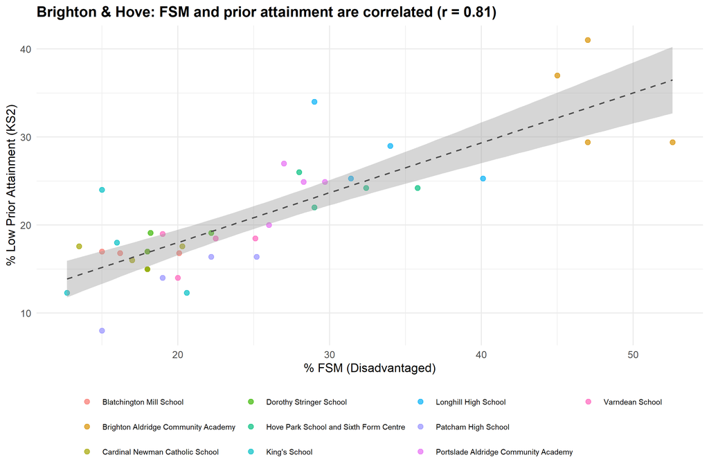

In Brighton & Hove, the correlation between log(% FSM) and % low prior attainment is **r = 0.81** — meaning schools with higher deprivation levels consistently receive pupils with weaker primary-school preparation. This is the mediating pathway in action: disadvantage leads to lower KS2 scores, which in turn predict lower KS4 attainment. Without controlling for prior attainment, any model would attribute this entire indirect effect to FSM alone.

In the full model (Analysis E), `PTPRIORLO` picks up the prior-attainment pathway of the disadvantage penalty, freeing `log(% FSM)` to capture only the *direct residual* relationship between intake composition and outcomes. This decomposition reveals something remarkable.

## 9.3 The FSM sign-flip: a structural finding only visible in the full model

The FSM coefficient flips sign for disadvantaged pupils once prior attainment is controlled for

| Pupil Group | Full Model (Analysis E) | Direction |
| --- | --- | --- |
| All Pupils | -0.06748 | Negative ↓ |
| Disadvantaged | 0.00765 | **Positive ↑** |
| Non-Disadvantaged | -0.04180 | Negative ↓ |

For **All Pupils** and **Non-Disadvantaged**, the FSM coefficient is negative as expected: higher deprivation is associated with lower attainment, even after controlling for prior attainment. But for **Disadvantaged pupils**, the coefficient flips to *positive*.

This means that, after accounting for prior attainment and all other controls, a school with a higher share of FSM-eligible pupils is predicted to achieve slightly *higher* attainment for its disadvantaged subgroup. The coefficient is small (+0.00765), but it is consistent across all years in the data, making it a stable structural finding rather than a statistical artefact.

**Why does this happen?** Two plausible explanations:

1. **The “critical mass” effect:** Schools serving predominantly disadvantaged cohorts may concentrate more resources — Pupil Premium funding, specialist teaching, pastoral support — on those pupils. Where disadvantaged pupils are a large share of the cohort, interventions are scaled rather than marginal.
2. **The composition effect:** In schools where almost all pupils are disadvantaged, the disadvantaged subgroup essentially *is* the school average, removing any within-school composition penalty.

**Crucially, this sign flip is invisible in a simpler model.** Without `PTPRIORLO` in the model, `log(% FSM)` is forced to absorb the indirect effect operating through prior attainment as well, and the net effect is negative for all three groups. The structural relationship is *suppressed* because the mediating pathway has not been separated out.

## 9.4 What this means for Brighton & Hove schools

Brighton & Hove schools: decomposing the disadvantage-related penalty into FSM, absence (confounder), and prior attainment (mediator) components (log-ATT8 scale)

| School | % FSM | % Absence | % Low Prior | FSM effect (All) | Absence effect (All) | Prior att. effect | Combined | FSM effect (Disadv.) |
| --- | --- | --- | --- | --- | --- | --- | --- | --- |
| Dorothy Stringer School | 18.2 | 9.8 | 19.1 | -0.196 | -0.486 | -0.110 | -0.792 | 0.022 |
| Blatchington Mill School | 20.1 | 10.8 | 16.8 | -0.202 | -0.507 | -0.097 | -0.806 | 0.023 |
| Cardinal Newman Catholic School | 20.3 | 8.5 | 17.6 | -0.203 | -0.456 | -0.101 | -0.760 | 0.023 |
| King’s School | 20.6 | 6.6 | 12.3 | -0.204 | -0.401 | -0.071 | -0.676 | 0.023 |
| Varndean School | 25.1 | 9.0 | 18.5 | -0.217 | -0.469 | -0.106 | -0.792 | 0.025 |
| Patcham High School | 25.2 | 7.9 | 16.4 | -0.218 | -0.442 | -0.094 | -0.754 | 0.025 |
| Portslade Aldridge Community Academy | 29.7 | 11.3 | 24.9 | -0.229 | -0.518 | -0.143 | -0.890 | 0.026 |
| Hove Park School and Sixth Form Centre | 35.8 | 12.9 | 24.2 | -0.241 | -0.545 | -0.139 | -0.925 | 0.027 |
| Longhill High School | 40.1 | 16.7 | 25.3 | -0.249 | -0.600 | -0.146 | -0.995 | 0.028 |
| Brighton Aldridge Community Academy | 52.6 | 14.4 | 29.4 | -0.267 | -0.569 | -0.169 | -1.005 | 0.030 |

The table above decomposes the model’s predicted penalty from intake composition into three parts for each Brighton & Hove school:

- **FSM effect:** the direct (residual) contribution of log(% FSM) × its coefficient
- **Absence effect:** the contribution of log(% absence) × its coefficient — a **confounder** correlated with FSM but not simply caused by it
- **Prior attainment effect:** the contribution of % low prior attainment × its coefficient — a **mediator** on the causal pathway from disadvantage to attainment

For **Brighton Aldridge Community Academy** (53% FSM, 14.4% absence, 29% low prior), the FSM effect on all-pupil attainment is -0.267 log points, the absence effect is -0.569, and the prior attainment effect is -0.169 — meaning prior attainment and absence together account for the bulk of the total intake-related penalty.

But look at the last column: the FSM effect *for disadvantaged pupils* at the same school is **+0.030** — positive. This school’s disadvantaged pupils are predicted to do slightly *better* precisely because it is a high-FSM school. Conversely, **Dorothy Stringer School** (18% FSM) has a FSM effect for disadvantaged pupils of +0.022 — smaller, because there are fewer disadvantaged peers.

## 9.5 Absence hits disadvantaged pupils hardest

The absence coefficient is largest (most negative) for disadvantaged pupils

| Pupil Group | Coefficient | Ratio to All |
| --- | --- | --- |
| All Pupils | -0.21323 | 1.00 |
| Disadvantaged | -0.30476 | 1.43 |
| Non-Disadvantaged | -0.17217 | 0.81 |

The absence coefficient for **disadvantaged pupils** (-0.30476) is **43% larger** in absolute terms than for all pupils (-0.21323). This means every unit of absence hits harder for the pupils who can least afford it.

Combined with the non-linear log transformation discussed above, this creates a double disadvantage:

1. **Disadvantaged pupils are more sensitive** to absence (larger coefficient)
2. **Schools with lower absence rates** see the biggest marginal effect (steeper curve)

For Brighton & Hove, this double disadvantage is compounded by a third factor: **the city is a national outlier on absence** (ranked 151st out of 152 LAs, with a mean school absence rate of 10.8% versus the national average of 8.2%). This means Brighton & Hove’s disadvantaged pupils face a triple penalty: they are more sensitive to absence *per unit*, they attend schools with absence rates far above the national norm, and the high baseline absence places their schools on the flatter part of the log curve where improvement is harder to achieve.

Crucially, this is not a simple correlate of deprivation. Brighton & Hove’s FSM rate sits at the 52nd percentile nationally — almost exactly at the median. Many local authorities with similar or higher levels of disadvantage achieve substantially lower absence rates. The absence problem is therefore amenable to local policy action rather than being an inevitable consequence of the city’s socioeconomic profile.

Absence reduction strategies targeted at schools with high absence rates — particularly those serving disadvantaged cohorts — therefore represent the single most effective lever the model identifies for closing the attainment gap, and the lever where Brighton & Hove has the most room for improvement.

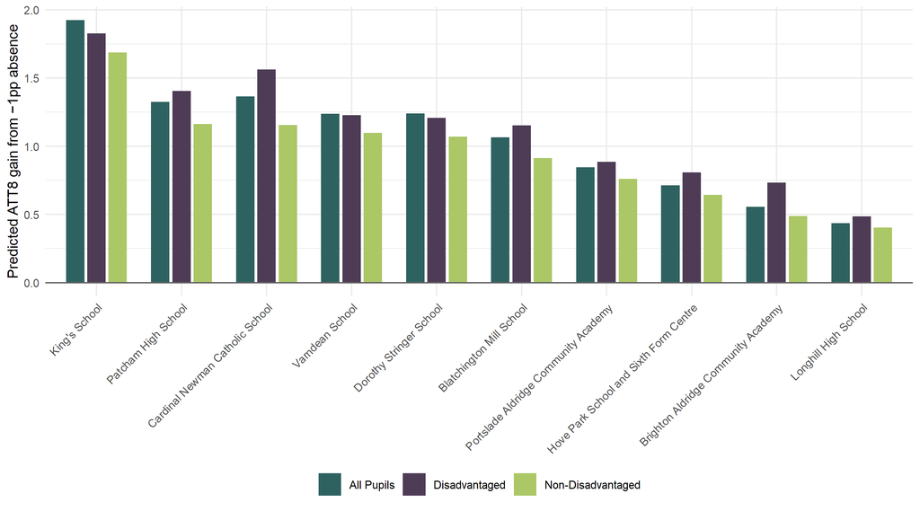

Predicted ATT8 gain from a 1pp absence reduction, by pupil group — the gap between disadvantaged and non-disadvantaged illustrates how absence reduction disproportionately benefits vulnerable pupils.

**ImportantMediation, confounding, and the story they tell**

The full model reveals that what appears to be a simple “disadvantage penalty” is actually a composite of distinct mechanisms:

1. **Prior attainment (mediation)** — the primary *mediating* pathway between deprivation and attainment. Schools with more disadvantaged intakes receive pupils with weaker KS2 preparation, and this indirect effect accounts for a large portion of the apparent FSM–attainment relationship. Once this mediator is included, the FSM coefficient captures only the direct residual effect of school-level deprivation.
2. **Residual deprivation** — once prior attainment is accounted for, higher FSM rates actually *help* disadvantaged pupils slightly (the sign flip), while still penalising overall and non-disadvantaged attainment.
3. **Absence (confounding)** — the strongest directly actionable predictor, hitting disadvantaged pupils hardest. Absence is correlated with FSM but is not simply caused by it, making it a confounder that inflates the apparent deprivation penalty in simpler models. Unlike FSM composition, absence can be influenced through policy and intervention, and the non-linear log scale means the greatest gains come from protecting schools with moderate absence rates. Brighton & Hove’s position as a national outlier on absence — but *not* on deprivation — makes this the defining policy challenge for the authority.

For Brighton & Hove, the practical conclusion is clear: **investing in absence reduction and KS2–KS3 transition support** will deliver far more than attempts to redistribute intake composition across schools. The fact that the city has near-average deprivation levels but near-worst absence rates demonstrates that the absence problem is not an inevitable consequence of its intake profile — and is therefore, in principle, solvable through targeted local action.

# 10 Observed vs Predicted

How well does the national model predict attainment for Brighton & Hove schools specifically? The scatter plot below shows **all schools nationally** in 2024-25 as grey points, with Brighton & Hove schools highlighted in pink and labelled by name. The dashed line marks perfect prediction — schools above the line are outperforming the model’s expectations; schools below are underperforming. The three panels show All Pupils, Disadvantaged, and Non-Disadvantaged outcomes.

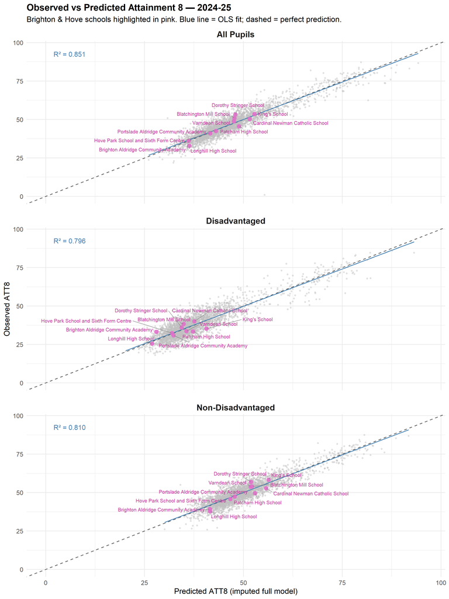

Observed vs predicted Attainment 8 for all schools (2024-25). Brighton & Hove schools highlighted in pink and labelled.

The plot reveals how each Brighton & Hove school sits relative to the full national distribution of predicted attainment. Schools well above the dashed line have positive residuals — they are achieving more than the model predicts given their intake and context. Schools below are underperforming relative to expectations.

## 10.1 Brighton & Hove schools across all years

The following plot focuses on **Brighton & Hove schools only**, showing how each school’s observed and predicted attainment tracks across all four years of the panel. Triangular markers indicate years where carry-forward imputed predictors were used (2024-25).

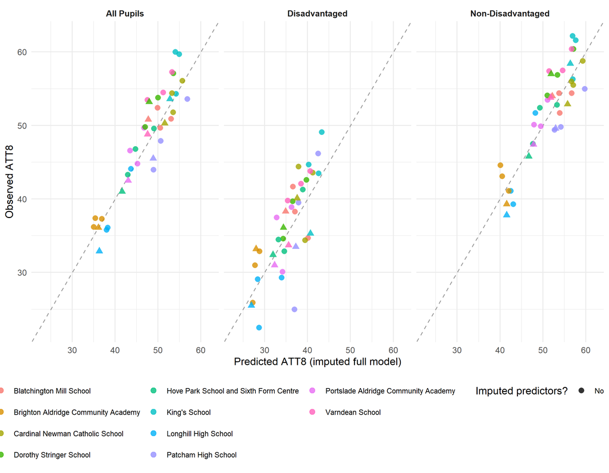

Observed vs model-predicted Attainment 8 for Brighton & Hove schools, faceted by pupil group. Points above the dashed line are outperforming expectations.

## 10.2 Interactive observed vs predicted

[interactive chart not shown]

# 11 Residuals by School

Model residuals — the difference between observed and predicted Attainment 8 — reveal which schools are **outperforming** (positive residual) or **underperforming** (negative residual) the model’s expectations, given their intake characteristics and context.

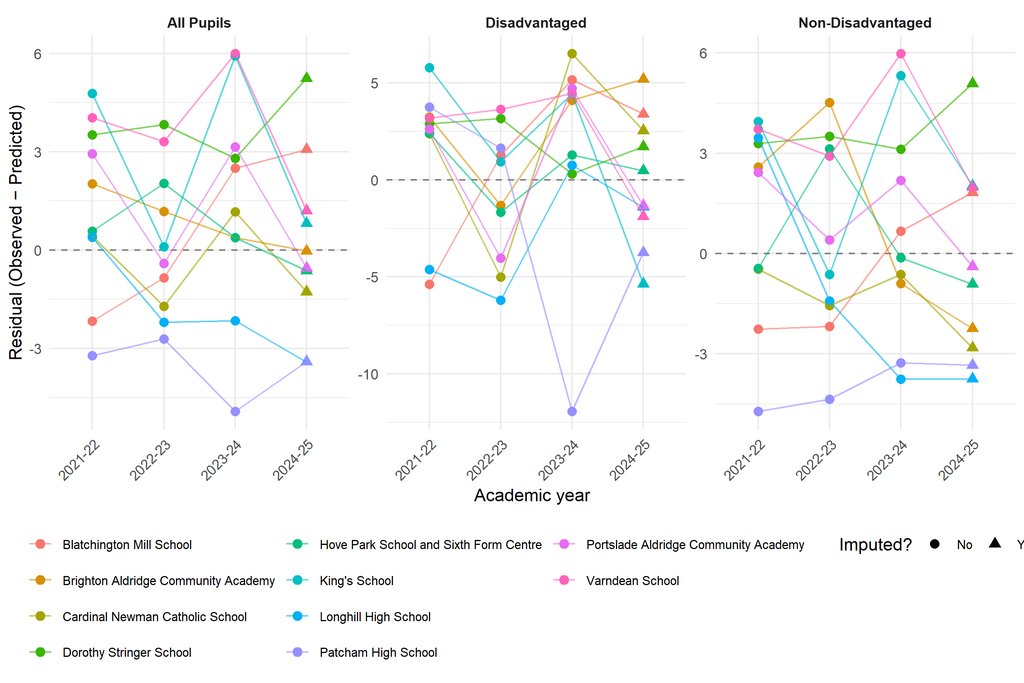

Model residuals (observed − predicted) for Brighton & Hove schools by outcome group and year. Schools above zero are outperforming the model’s expectations.

## 11.1 Interactive residuals

[interactive chart not shown]

## 11.2 Residual map

[interactive chart not shown]

Brighton & Hove schools coloured by mean model residual across all panel years. Use the dropdown to switch between outcome groups. Green = outperforming, red = underperforming.

Use the dropdown above the map to switch between outcome groups: **All Pupils**, **Disadvantaged**, and **Non-Disadvantaged**. The residuals shown are *mean values across all panel years* — the same figures used to rank schools in the value-added league tables in Section 13 below. Schools shown in green are outperforming the model’s expectations given their intake, context, and workforce characteristics, while schools in red are underperforming. Circle size reflects the magnitude of the residual. Click any marker to see the full breakdown of residuals across all three groups, including observed and predicted scores and the number of years contributing to the average. The spatial pattern can reveal whether there are area-level factors — community resources, transport links, local employment conditions — that the model does not capture.

# 12 Brighton & Hove in National Context

Brighton & Hove schools: position within national quartiles (most recent year)

| School | % FSM | FSM Quartile | % Absence | Absence Quartile | % EAL | EAL Quartile |
| --- | --- | --- | --- | --- | --- | --- |
| Blatchington Mill School | 20.1 | Q2 | 10.8 | Top 25% | 16.1 | Q3 |
| Brighton Aldridge Community Academy | 52.6 | Top 25% | 14.4 | Top 25% | 12.2 | Q3 |
| Cardinal Newman Catholic School | 20.3 | Q2 | 8.5 | Q2 | 22.7 | Q3 |
| Dorothy Stringer School | 18.2 | Q2 | 9.8 | Q3 | 7.9 | Q2 |
| Hove Park School and Sixth Form Centre | 35.8 | Q3 | 12.9 | Top 25% | 29.2 | Top 25% |
| King’s School | 20.6 | Q2 | 6.6 | Bottom 25% | 9.6 | Q2 |
| Longhill High School | 40.1 | Top 25% | 16.7 | Top 25% | 7.4 | Q2 |
| Patcham High School | 25.2 | Q3 | 7.9 | Q2 | 7.5 | Q2 |
| Portslade Aldridge Community Academy | 29.7 | Q3 | 11.3 | Top 25% | 8.1 | Q2 |
| Varndean School | 25.1 | Q3 | 9.0 | Q3 | 9.7 | Q2 |

The table above places each Brighton & Hove school within the national distribution of key predictors. This context is essential for understanding the non-linear effects discussed in Section 8: schools in the lower quartiles sit on the steep part of the log curve where small absolute changes have the largest predicted impact.

# 13 An Alternative League Table: Value Added by School

Traditional school league tables rank schools by raw Attainment 8 scores. But this conflates school *quality* with school *intake*: schools serving affluent, well-prepared cohorts will always appear near the top, while schools facing greater challenges are penalised regardless of the value they add.

The model residual — observed ATT8 minus predicted ATT8 — offers an alternative. A positive residual means a school is achieving *more* than the model predicts given its intake composition, absence rates, prior attainment, workforce stability, and area characteristics. A negative residual means it is achieving *less*. This is conceptually similar to a **value-added** measure: how much is the school contributing beyond what would be expected from its circumstances?

**NoteHow to read these tables**

- **Positive residuals (green)** → the school is outperforming expectations. The larger the number, the more the school is adding above what the model predicts.
- **Negative residuals (red)** → the school is underperforming expectations. The school may still have good raw results, but its circumstances predict even better outcomes.
- **Near zero** → the school is performing roughly as the model expects.
- Schools are ranked by their **mean residual across all available years** for the panel model.

## 13.1 All Pupils

All Pupils: value-added rankings (panel model residuals by year)

| Rank | School | 2021-22 | 2022-23 | 2023-24 | 2024-25 | Mean Residual |
| --- | --- | --- | --- | --- | --- | --- |
| 1 | Dorothy Stringer School | +3.5 | +3.8 | +2.8 | +5.2 | +3.8 |
| 2 | Varndean School | +4.0 | +3.3 | +6.0 | +1.2 | +3.6 |
| 3 | King's School | +4.8 | +0.1 | +5.9 | +0.8 | +2.9 |
| 4 | Portslade Aldridge Community Academy | +2.9 | -0.4 | +3.1 | -0.5 | +1.3 |
| 5 | Brighton Aldridge Community Academy | +2.0 | +1.2 | +0.4 | -0.0 | +0.9 |
| 6 | Blatchington Mill School | -2.2 | -0.8 | +2.5 | +3.1 | +0.6 |
| 7 | Hove Park School and Sixth Form Centre | +0.6 | +2.0 | +0.4 | -0.6 | +0.6 |
| 8 | Cardinal Newman Catholic School | +0.4 | -1.7 | +1.2 | -1.3 | -0.3 |
| 9 | Longhill High School | +0.4 | -2.2 | -2.2 | -3.4 | -1.8 |
| 10 | Patcham High School | -3.2 | -2.7 | -4.9 | -3.4 | -3.6 |

All Pupils: value-added rankings (per-year model residuals)

| Rank | School | 2021-22 | 2022-23 | 2023-24 | 2024-25 | Mean Residual |
| --- | --- | --- | --- | --- | --- | --- |
| 1 | Dorothy Stringer School | +3.9 | +5.2 | +4.2 | +7.2 | +5.1 |
| 2 | Varndean School | +4.6 | +4.5 | +7.2 | +3.1 | +4.9 |
| 3 | King's School | +6.3 | +1.0 | +6.9 | +2.7 | +4.2 |
| 4 | Portslade Aldridge Community Academy | +3.4 | +0.5 | +4.4 | +1.1 | +2.3 |
| 5 | Blatchington Mill School | -1.9 | +0.2 | +3.6 | +5.1 | +1.8 |
| 6 | Brighton Aldridge Community Academy | +2.3 | +2.2 | +1.4 | +1.2 | +1.8 |
| 7 | Hove Park School and Sixth Form Centre | +1.1 | +2.9 | +1.4 | +0.9 | +1.6 |
| 8 | Cardinal Newman Catholic School | +0.6 | -0.4 | +2.8 | +0.6 | +0.9 |
| 9 | Longhill High School | +0.5 | -1.0 | -1.1 | -2.0 | -0.9 |
| 10 | Patcham High School | -2.1 | -1.8 | -3.8 | -1.4 | -2.3 |

## 13.2 Disadvantaged Pupils

Disadvantaged Pupils: value-added rankings (panel model residuals by year)

| Rank | School | 2021-22 | 2022-23 | 2023-24 | 2024-25 | Mean Residual |
| --- | --- | --- | --- | --- | --- | --- |
| 1 | Brighton Aldridge Community Academy | +3.2 | -1.3 | +4.1 | +5.2 | +2.8 |
| 2 | Varndean School | +3.2 | +3.6 | +4.5 | -1.9 | +2.3 |
| 3 | Dorothy Stringer School | +2.9 | +3.2 | +0.3 | +1.7 | +2.0 |
| 4 | Cardinal Newman Catholic School | +2.4 | -5.0 | +6.5 | +2.5 | +1.6 |
| 5 | King's School | +5.8 | +0.9 | +4.4 | -5.4 | +1.5 |
| 6 | Blatchington Mill School | -5.4 | +1.3 | +5.2 | +3.4 | +1.1 |
| 7 | Hove Park School and Sixth Form Centre | +2.4 | -1.7 | +1.3 | +0.5 | +0.6 |
| 8 | Portslade Aldridge Community Academy | +2.6 | -4.0 | +4.7 | -1.3 | +0.5 |
| 9 | Patcham High School | +3.8 | +1.6 | -11.9 | -3.7 | -2.6 |
| 10 | Longhill High School | -4.6 | -6.2 | +0.8 | -1.4 | -2.9 |

Disadvantaged Pupils: value-added rankings (per-year model residuals)

| Rank | School | 2021-22 | 2022-23 | 2023-24 | 2024-25 | Mean Residual |
| --- | --- | --- | --- | --- | --- | --- |
| 1 | Brighton Aldridge Community Academy | +3.1 | -0.2 | +4.2 | +5.8 | +3.2 |
| 2 | Varndean School | +3.6 | +5.4 | +4.5 | -1.0 | +3.1 |
| 3 | Dorothy Stringer School | +3.0 | +5.0 | +0.5 | +2.7 | +2.8 |
| 4 | King's School | +7.3 | +2.9 | +3.8 | -4.4 | +2.4 |
| 5 | Cardinal Newman Catholic School | +2.1 | -3.1 | +7.0 | +3.1 | +2.3 |
| 6 | Blatchington Mill School | -5.3 | +3.0 | +5.1 | +4.7 | +1.9 |
| 7 | Hove Park School and Sixth Form Centre | +2.7 | -0.4 | +1.3 | +1.3 | +1.2 |
| 8 | Portslade Aldridge Community Academy | +3.1 | -2.8 | +4.8 | -0.4 | +1.2 |
| 9 | Patcham High School | +4.4 | +3.1 | -12.3 | -2.8 | -1.9 |
| 10 | Longhill High School | -4.6 | -4.8 | +1.0 | -0.5 | -2.2 |

## 13.3 Non-Disadvantaged Pupils

Non-Disadvantaged Pupils: value-added rankings (panel model residuals by year)

| Rank | School | 2021-22 | 2022-23 | 2023-24 | 2024-25 | Mean Residual |
| --- | --- | --- | --- | --- | --- | --- |
| 1 | Dorothy Stringer School | +3.3 | +3.5 | +3.1 | +5.1 | +3.7 |
| 2 | Varndean School | +3.7 | +2.9 | +6.0 | +2.0 | +3.7 |
| 3 | King's School | +3.9 | -0.6 | +5.3 | +2.0 | +2.7 |
| 4 | Portslade Aldridge Community Academy | +2.4 | +0.4 | +2.2 | -0.4 | +1.2 |
| 5 | Brighton Aldridge Community Academy | +2.6 | +4.5 | -0.9 | -2.2 | +1.0 |
| 6 | Hove Park School and Sixth Form Centre | -0.4 | +3.1 | -0.1 | -0.9 | +0.4 |
| 7 | Blatchington Mill School | -2.3 | -2.2 | +0.7 | +1.8 | -0.5 |
| 8 | Longhill High School | +3.5 | -1.4 | -3.8 | -3.7 | -1.4 |
| 9 | Cardinal Newman Catholic School | -0.5 | -1.6 | -0.6 | -2.8 | -1.4 |
| 10 | Patcham High School | -4.7 | -4.4 | -3.3 | -3.3 | -3.9 |

Non-Disadvantaged Pupils: value-added rankings (per-year model residuals)

| Rank | School | 2021-22 | 2022-23 | 2023-24 | 2024-25 | Mean Residual |
| --- | --- | --- | --- | --- | --- | --- |
| 1 | Dorothy Stringer School | +3.8 | +4.8 | +4.0 | +6.5 | +4.8 |
| 2 | Varndean School | +4.4 | +4.0 | +6.8 | +3.5 | +4.7 |
| 3 | King's School | +5.8 | +0.4 | +5.8 | +3.4 | +3.8 |
| 4 | Portslade Aldridge Community Academy | +3.3 | +1.3 | +2.8 | +0.8 | +2.1 |
| 5 | Brighton Aldridge Community Academy | +3.1 | +5.7 | -0.3 | -1.3 | +1.8 |
| 6 | Hove Park School and Sixth Form Centre | +0.4 | +4.0 | +0.5 | +0.2 | +1.3 |
| 7 | Blatchington Mill School | -1.8 | -1.0 | +1.1 | +3.5 | +0.5 |
| 8 | Cardinal Newman Catholic School | -0.1 | -0.4 | +0.3 | -1.4 | -0.4 |
| 9 | Longhill High School | +3.9 | -0.0 | -3.2 | -2.7 | -0.5 |
| 10 | Patcham High School | -3.8 | -3.4 | -2.7 | -1.8 | -2.9 |

## 13.4 Summary: Combined Value-Added Heatmap

[interactive chart not shown]

Value-added heatmap: panel model residuals for all Brighton & Hove schools, by year and pupil group. Green = outperforming, red = underperforming, white = as expected.

## 13.5 Orientation Map: Schools and Proposed Catchments

[interactive chart not shown]

Brighton & Hove secondary schools with 2025/26 catchment boundaries. Click a logo or marker to see the school name.

The map above shows each Brighton & Hove secondary school at its geographic location, marked with the school’s logo, and overlaid with the 2025/26 catchment boundaries. Shared catchment areas (e.g. Varndean/Dorothy Stringer, Hove Park/Blatchington Mill) are shown as single zones. Click on any logo or dot for key school statistics.

## 13.6 School-by-School Commentary

[figure not shown]

### Dorothy Stringer School

*Good-rated school | Mean ATT8: 53.5 | Mean % FSM: 19.1% | Mean % Absence: 10.1%*

Dorothy Stringer School is **substantially outperforming** the model’s expectations, with residuals consistently positive in every year (mean residual: **+3.8** ATT8 points for all pupils). The residuals show an **improving trend** over time. The school’s value-added is **weaker for disadvantaged pupils** (mean residual +2.0) than for non-disadvantaged (+3.7), suggesting room for more targeted support.

[figure not shown]

### Varndean School

*Good-rated school | Mean ATT8: 53.5 | Mean % FSM: 21.6% | Mean % Absence: 9.2%*

Varndean School is **substantially outperforming** the model’s expectations, with residuals consistently positive in every year (mean residual: **+3.6** ATT8 points for all pupils). The residuals show **no clear trend** over time. The school’s value-added is **weaker for disadvantaged pupils** (mean residual +2.3) than for non-disadvantaged (+3.7), suggesting room for more targeted support.

[figure not shown]

### King’s School

*Good-rated school | Mean ATT8: 56.9 | Mean % FSM: 16.1% | Mean % Absence: 6.6%*

King’s School is **outperforming** the model’s expectations, with residuals consistently positive in every year (mean residual: **+2.9** ATT8 points for all pupils). The residuals show **no clear trend** over time. The school’s value-added is **weaker for disadvantaged pupils** (mean residual +1.5) than for non-disadvantaged (+2.7), suggesting room for more targeted support.

[figure not shown]

### Portslade Aldridge Community Academy

*Good-rated school | Mean ATT8: 45.9 | Mean % FSM: 27.8% | Mean % Absence: 11.7%*

Portslade Aldridge Community Academy is **outperforming** the model’s expectations, with residuals positive in 2 of 4 years (mean residual: **+1.3** ATT8 points for all pupils). The residuals show **no clear trend** over time.

[figure not shown]

### Brighton Aldridge Community Academy

*Requires Improvement-rated school | Mean ATT8: 36.8 | Mean % FSM: 47.9% | Mean % Absence: 15.8%*

Brighton Aldridge Community Academy is **performing broadly in line with** the model’s expectations, with residuals positive in 3 of 4 years (mean residual: **+0.9** ATT8 points for all pupils). The residuals show a **declining trend** over time. Notably, the school’s value-added for **disadvantaged pupils** (mean residual +2.8) is stronger than for non-disadvantaged pupils (+1.0), suggesting particularly effective support for its most vulnerable students.

[figure not shown]

### Blatchington Mill School

*Good-rated school | Mean ATT8: 51.0 | Mean % FSM: 17.3% | Mean % Absence: 10.1%*

Blatchington Mill School is **performing broadly in line with** the model’s expectations, with residuals positive in 2 of 4 years (mean residual: **+0.6** ATT8 points for all pupils). The residuals show an **improving trend** over time. Notably, the school’s value-added for **disadvantaged pupils** (mean residual +1.1) is stronger than for non-disadvantaged pupils (-0.5), suggesting particularly effective support for its most vulnerable students.

[figure not shown]

### Hove Park School and Sixth Form Centre

*Good-rated school | Mean ATT8: 45.2 | Mean % FSM: 31.3% | Mean % Absence: 11.8%*

Hove Park School and Sixth Form Centre is **performing broadly in line with** the model’s expectations, with residuals positive in 3 of 4 years (mean residual: **+0.6** ATT8 points for all pupils). The residuals show a **declining trend** over time.

[figure not shown]

### Cardinal Newman Catholic School

*Good-rated school | Mean ATT8: 53.1 | Mean % FSM: 17.2% | Mean % Absence: 9.0%*

Cardinal Newman Catholic School is **performing broadly in line with** the model’s expectations, with residuals positive in 2 of 4 years (mean residual: **-0.3** ATT8 points for all pupils). The residuals show **no clear trend** over time. Notably, the school’s value-added for **disadvantaged pupils** (mean residual +1.6) is stronger than for non-disadvantaged pupils (-1.4), suggesting particularly effective support for its most vulnerable students.

[figure not shown]

### Longhill High School

*Good-rated school | Mean ATT8: 37.2 | Mean % FSM: 33.6% | Mean % Absence: 14.7%*

Longhill High School is **underperforming** the model’s expectations, with residuals positive in 1 of 4 years (mean residual: **-1.8** ATT8 points for all pupils). The residuals show a **declining trend** over time. The school’s value-added is **weaker for disadvantaged pupils** (mean residual -2.9) than for non-disadvantaged (-1.4), suggesting room for more targeted support.

[figure not shown]

### Patcham High School

*Good-rated school | Mean ATT8: 47.8 | Mean % FSM: 20.4% | Mean % Absence: 8.8%*

Patcham High School is **substantially underperforming** the model’s expectations, with residuals negative in every year observed (mean residual: **-3.6** ATT8 points for all pupils). The residuals show **no clear trend** over time. Notably, the school’s value-added for **disadvantaged pupils** (mean residual -2.6) is stronger than for non-disadvantaged pupils (-3.9), suggesting particularly effective support for its most vulnerable students.

**TipUsing this alternative league table**

These residual-based rankings provide a fairer comparison between schools than raw Attainment 8 scores. A school ranked first in this table is not necessarily the highest-scoring school in Brighton & Hove, but it is the school that is adding the most value relative to what would be expected given its circumstances.

For the council and school improvement teams, the most actionable insights come from:

- **Consistently positive schools** — what are they doing differently that could be shared across the authority?
- **Consistently negative schools** — where might additional support or intervention be most impactful?
- **Schools with divergent group residuals** — where the value-added for disadvantaged pupils differs markedly from non-disadvantaged, either positively or negatively.
- **Year-on-year trends** — schools whose residuals are improving or declining over time may signal changing effectiveness or emerging challenges.

# 14 Interpretation: What the Model Tells Us About Brighton & Hove

## 14.1 The FSM sign-flip

The model reveals a striking pattern in how deprivation relates to attainment across different pupil groups. For the **All Pupils** and **Non-Disadvantaged** models, the coefficient on `log(% FSM)` is *negative* — schools with higher deprivation levels achieve lower predicted attainment, as expected. But for the **Disadvantaged** model, the coefficient flips to *positive*: schools with higher FSM rates actually receive a modest upward adjustment for their disadvantaged pupils’ predicted attainment.

In Brighton & Hove, this plays out clearly. Schools with lower FSM rates benefit from the negative coefficient for overall attainment (lower deprivation → higher predicted score). But for disadvantaged pupils specifically, schools with higher FSM rates — where disadvantaged pupils form a larger share of the cohort — get a slight prediction boost. The model is capturing the idea that disadvantaged pupils may do relatively better in schools where they are not a small, potentially marginalised minority.

**TipPolicy implication**

Schools with lower FSM proportions should consider whether their disadvantaged pupils receive sufficiently **targeted** support, or whether Pupil Premium resources are diluted across the whole cohort. The model suggests that concentrated, well-resourced intervention may be more effective than spread-thin approaches.

## 14.2 Absence: the biggest lever

Across all three pupil groups, overall absence rate is consistently one of the strongest predictors of Attainment 8. The log-transformed relationship means that gains from reducing absence are **largest for schools with already-moderate absence rates** — the steep part of the curve.

For Brighton & Hove schools with relatively low absence rates, even a small absolute increase (e.g. 4.5% to 5.5%) translates into a meaningful drop in predicted attainment. In contrast, a school already at 8% or 9% absence would need a larger absolute rise to see the same predicted impact.

This has two implications:

1. **Protecting low-absence schools from deterioration** is just as important as tackling chronic absence elsewhere
2. **Early intervention** before absence becomes entrenched is more efficient than remediation later

## 14.3 Workforce effects

The imputed full model includes teacher retention (`remained_in_the_same_school`) and teacher sickness days (`average_number_of_days_taken`) as predictors. In Brighton & Hove:

- Schools with **higher staff stability** receive a positive adjustment to predicted attainment
- Schools with **higher teacher absence** see a penalty

These effects are visible in the school-level residuals: schools that previously appeared to over- or under-perform the core model (which lacked workforce variables) may now be better explained by the additional workforce predictors. Where persistent residuals remain after controlling for workforce factors, they point to genuinely unmeasured factors — leadership quality, curriculum design, community resources — rather than being artefacts of missing controls.

## 14.4 What the residuals mean

**NoteA note on 2024-25**

Points shown as triangles (▲) in the plots use carry-forward imputed values for four predictors. These predictions should be treated with somewhat more caution than those based on directly observed data.

# 15 Variable Importance: National vs Brighton & Hove

## 15.1 National rankings

National variable importance: standardised coefficients (Analysis E)

| Rank | display_name | All Pupils | Disadvantaged | Non-Disadvantaged | Avg \|Std. Coef\| |
| --- | --- | --- | --- | --- | --- |
| 1 | Overall Absence Rate | -0.0610 | -0.0871 | -0.0492 | 0.0658 |
| 2 | % Low Prior Attainment | -0.0587 | -0.0543 | -0.0531 | 0.0554 |
| 3 | % Disadvantaged (FSM) | -0.0415 | 0.0047 | -0.0257 | 0.0240 |
| 4 | % EAL | 0.0066 | 0.0261 | 0.0090 | 0.0139 |
| 5 | Teacher Retention | 0.0106 | 0.0006 | 0.0098 | 0.0070 |
| 6 | Teacher Sickness Days | -0.0057 | -0.0072 | -0.0068 | 0.0066 |
| 7 | Leadership Pay % | -0.0053 | -0.0038 | -0.0055 | 0.0049 |
| 8 | Gorard Segregation Index | -0.0015 | -0.0002 | -0.0025 | 0.0014 |

[interactive chart not shown]

## 15.2 Brighton & Hove rankings

The same standardised-coefficient approach is repeated using only Brighton & Hove schools. Because the local predictor distributions may differ from the national picture (e.g. narrower absence range, different FSM spread), the variable importance rankings may shift.

Brighton & Hove variable importance: standardised coefficients (local predictor SDs, national model)

| Rank | display_name | All Pupils | Disadvantaged | Non-Disadvantaged | Avg \|Std. Coef\| |
| --- | --- | --- | --- | --- | --- |
| 1 | Overall Absence Rate | -0.0544 | -0.0778 | -0.0439 | 0.0587 |
| 2 | % Low Prior Attainment | -0.0400 | -0.0370 | -0.0362 | 0.0378 |
| 3 | % Disadvantaged (FSM) | -0.0248 | 0.0028 | -0.0154 | 0.0143 |
| 4 | Teacher Retention | 0.0146 | 0.0008 | 0.0135 | 0.0096 |
| 5 | % EAL | 0.0028 | 0.0112 | 0.0038 | 0.0059 |
| 6 | Teacher Sickness Days | -0.0041 | -0.0051 | -0.0049 | 0.0047 |
| 7 | Leadership Pay % | -0.0037 | -0.0027 | -0.0038 | 0.0034 |
| 8 | Gorard Segregation Index | -0.0002 | 0.0000 | -0.0003 | 0.0002 |

[interactive chart not shown]

## 15.3 Comparison

All Pupils: national vs Brighton & Hove variable importance rankings

| display_name | National Rank | National Std.Coef | B&H Rank | B&H Std.Coef | Rank Change |
| --- | --- | --- | --- | --- | --- |
| Overall Absence Rate | 1 | -0.0610 | 1 | -0.0544 | 0 |
| % Low Prior Attainment | 2 | -0.0587 | 2 | -0.0400 | 0 |
| % Disadvantaged (FSM) | 3 | -0.0415 | 3 | -0.0248 | 0 |
| % EAL | 4 | 0.0066 | 5 | 0.0028 | -1 |
| Teacher Retention | 5 | 0.0106 | 4 | 0.0146 | 1 |
| Teacher Sickness Days | 6 | -0.0057 | 6 | -0.0041 | 0 |
| Leadership Pay % | 7 | -0.0053 | 7 | -0.0037 | 0 |
| Gorard Segregation Index | 8 | -0.0015 | 8 | -0.0002 | 0 |

Disadvantaged Pupils: national vs Brighton & Hove variable importance rankings

| display_name | National Rank | National Std.Coef | B&H Rank | B&H Std.Coef | Rank Change |
| --- | --- | --- | --- | --- | --- |
| Overall Absence Rate | 1 | -0.0871 | 1 | -0.0778 | 0 |
| % Low Prior Attainment | 2 | -0.0543 | 2 | -0.0370 | 0 |
| % EAL | 3 | 0.0261 | 3 | 0.0112 | 0 |
| Teacher Sickness Days | 4 | -0.0072 | 4 | -0.0051 | 0 |
| % Disadvantaged (FSM) | 5 | 0.0047 | 5 | 0.0028 | 0 |
| Leadership Pay % | 6 | -0.0038 | 6 | -0.0027 | 0 |
| Teacher Retention | 7 | 0.0006 | 7 | 0.0008 | 0 |
| Gorard Segregation Index | 8 | -0.0002 | 8 | 0.0000 | 0 |

### 15.3.1 Key differences between national and local rankings

# 16 Neighbourhood Context: The Educated City

*(Added June 2026, following Analysis F in `model_experiments.qmd`.)*

Brighton & Hove ranks near the top of the LA caterpillar plots — among the best places in England for attainment once cohort composition, prior attainment, absence and workforce are accounted for. But the caterpillar’s LA effect is a residual: it absorbs *everything place-shaped the model cannot see*. One candidate is obvious in this city: an unusually educated populace. If graduate-rich neighbourhoods lift children’s attainment through channels the school-level variables miss — home learning environments, peer expectations, social networks — then part of Brighton & Hove’s apparent over-performance belongs to the city, not its schools or its council.

We can now test this. The census context dataset (`R/13_census_context.R`) measures, for every school, the share of adults with level 4+ qualifications across its 50 nearest output areas. Adding these neighbourhood measures to the national model moves “educated populace” out of the LA residual and into the measured part of the model — and lets us watch what happens to Brighton & Hove’s ranking.

## 16.1 How educated are the neighbourhoods B&H schools serve?

```
B&H secondary schools' mean neighbourhood % level 4+: 42.1
National mean: 33.2
B&H mean sits at roughly the 80 th percentile of school neighbourhoods
```

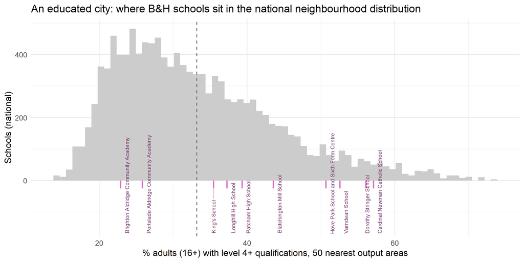

Figure 4: Neighbourhood adult education for England’s state secondary schools; Brighton & Hove schools marked.

## 16.2 What happens to the LA league table — and to Brighton & Hove

The national model (identical to the one above) refitted with and without the neighbourhood terms, for all pupils and for disadvantaged pupils:

Brighton & Hove’s LA effect and national rank, before and after neighbourhood context (152 LAs; rank 1 = best)

| Model | LA effect (baseline) | Rank (baseline) | LA effect (+ census) | Rank (+ census) | Share of effect explained by neighbourhoods |
| --- | --- | --- | --- | --- | --- |
| All pupils | 0.0568 | 4 | 0.0375 | 6 | 34% |
| Disadvantaged pupils | 0.0504 | 7 | 0.0401 | 13 | 20% |

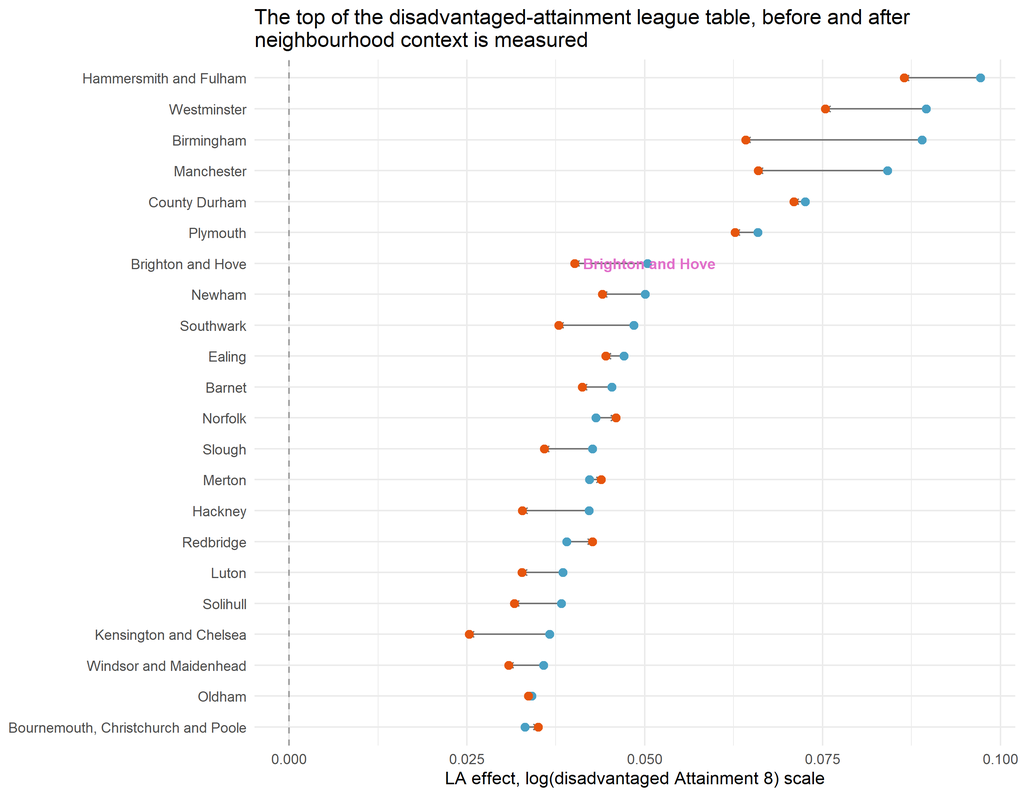

Figure 5: LA effects for disadvantaged pupils before (blue) and after (orange) neighbourhood context: top 20 LAs plus any large fallers. Brighton & Hove highlighted.

Reading the result: for all pupils, measuring neighbourhood context explains **34% of Brighton & Hove’s LA effect**, moving the city from 4th to 6th of 152; for disadvantaged pupils it explains **20%**, moving it from 7th to 13th. So a meaningful share of the city’s apparent over-performance *is* its educated populace — but a city this educated dropping only a few places means the conclusion of the main analysis survives the strongest contextual control we can construct: Brighton & Hove’s schools still deliver attainment above what their cohorts *and* their neighbourhoods would predict.

## 16.3 The city’s schools in their neighbourhoods

Table 3: B&H secondary schools: neighbourhood context and residual performance once cohort AND neighbourhood are accounted for

| SCHNAME | Nbhd % L4+ (k=50) | Mean Att8 | School residual (census model, log pts) |
| --- | --- | --- | --- |
| Cardinal Newman Catholic School | 57.1 | 53.1 | -0.035 |
| Dorothy Stringer School | 56.1 | 53.5 | 0.045 |
| Varndean School | 52.6 | 53.5 | 0.048 |
| Hove Park School and Sixth Form Centre | 50.7 | 45.2 | -0.006 |
| Blatchington Mill School | 43.6 | 51.0 | 0.018 |
| Patcham High School | 39.3 | 47.8 | -0.059 |
| Longhill High School | 37.3 | 37.2 | -0.048 |
| King’s School | 35.4 | 56.9 | 0.076 |
| Portslade Aldridge Community Academy | 25.8 | 45.9 | 0.062 |
| Brighton Aldridge Community Academy | 22.9 | 36.8 | 0.040 |

The table contradicts any notion that an “educated city” is educated uniformly: B&H schools’ neighbourhood context spans from the low-20s% level-4+ (the two Aldridge academies, in the city’s east) to the mid-50s% (Cardinal Newman, Dorothy Stringer, Varndean) — a range covering most of the national distribution *within a single small city*. The schools serving the city’s least-educated neighbourhoods are precisely the ones that raw league tables criticise; the residual column — each school’s persistent departure from expectation *after* its cohort and its neighbourhoods — is the fairest single-number school comparison this analysis can currently produce, and it tells a different story from the raw Attainment 8 column beside it. (The k = 50 construction still blurs finer intra-urban structure; the feeder-calibration work in the research programme would sharpen this further.)

## 16.4 How much do schools actually move outcomes?

The decomposition in `model_experiments.qmd` (Analysis F) puts magnitudes on the question underlying the city’s admissions debate. In the national census-context model with a school-level random intercept, the variance of school Attainment 8 splits roughly as:

- **~65% — the hand each school is dealt**: cohort composition, prior attainment, absence, workforce and neighbourhood context (fixed effects);
- **~16% — the persistent school effect**: the same school over- or under-shooting expectation year after year (≈ 3.5 Attainment 8 points per standard deviation) — and this is an *upper bound* on what the school itself adds, because it also absorbs stable unmeasured intake sorting;
- **~10% — transient cohort-year noise**; the remainder is Ofsted-, year- and place-level.

The implication for policies that reallocate pupils between schools is direct. Moving a child changes *which building they sit in* — the ~16%-at-most component — while leaving unchanged their prior attainment, their home neighbourhood, and (not directly) their attendance: the variables doing two-thirds of the work. Even moving a child from an average school to one a full standard deviation better is worth a few Attainment 8 points at the upper bound — before netting out the catchment-sorting share of that school effect, and before weighing the costs (travel, disruption, severed peer networks) the consultation literature documents. None of this says schools do not matter — a persistent 3-4 point school effect is real and worth pursuing through school improvement. It says that **redistribution between schools is a weak lever for the stated goal**, while the strong levers — attendance, and the long shadow of early attainment and neighbourhood conditions — operate before and outside the admissions system.

# 17 Policy Recommendations

The variable importance rankings, combined with the non-linear effects and Brighton & Hove’s local context, suggest several priority areas.

## 17.1 For school leaders

**1. Absence reduction is the single biggest lever.**

The log-transformed relationship means that gains from reducing absence are largest for schools with already-moderate absence rates. For a school currently at 6% absence, reducing to 5% has a larger predicted effect than a school at 10% reducing to 9%. This argues for intensive early-intervention strategies before absence becomes entrenched, and for protecting low-absence schools from deterioration.

**2. Support for pupils with low prior attainment.**

The % low prior attainment coefficient is strongly negative. While schools cannot change their intake, they can invest in targeted catch-up programmes at the KS2-KS3 transition, diagnostic assessment, and small-group intervention during KS3.

**3. Workforce stability matters.**

Teacher retention shows a positive association with attainment; teacher sickness shows a negative one. Retention strategies (competitive CPD, workload management, mentoring for early-career teachers) and staff wellbeing programmes can both contribute.

**4. The FSM sign-flip for disadvantaged pupils.**

Schools with lower FSM proportions should consider whether their disadvantaged pupils receive sufficiently targeted support, or whether Pupil Premium resources are diluted across the whole cohort.

## 17.2 For Brighton & Hove Council

**1. Tackle absence strategically across the authority** through coordinated data sharing, targeted outreach, and shared best practice between schools.

**2. Address the disadvantaged attainment gap directly** by ring-fencing and monitoring Pupil Premium impact, commissioning cross-school programmes, and tracking the FSM gap as a headline KPI using the model’s predicted-vs-actual framework.

**3. A note on segregation:** The Gorard segregation index is statistically insignificant in this model. While reducing segregation may be a worthwhile policy goal for broader equity reasons, this model does not provide reliable evidence that it would improve Attainment 8 scores at school level.

**4. Support workforce stability** through LA-wide recruitment initiatives, monitoring teacher turnover across schools, and ensuring schools in challenging contexts receive additional staffing support.

**5. Use the model to target support** via the Shiny app’s policy simulator, which allows exploration of school-level what-if scenarios. The residual analysis identifies schools outperforming expectations — learn from their practices — and those underperforming — target support where it is most needed.

**WarningImportant caveat**

These recommendations are based on *associations* identified by the multilevel model. The model controls for observable confounders but **cannot establish causation**. A school reducing absence may not see exactly the predicted ATT8 gain if other unmeasured factors change simultaneously. The rankings and effect sizes should be treated as evidence-informed starting points for policy discussion, not as causal guarantees.

[UCL Centre for Advanced Spatial Analysis](https://www.ucl.ac.uk/bartlett/casa) · School Attainment Tool